# 4.1 — Modeling Firms With Market Power — Practice Problems

Solutions

ECON 306 - Fall 2022

Bob’s Bats produces baseball bats, and has the following costs:
$$\begin{aligned}
C(q)&=5q^2+720\\
MC(q)&=10q\\
\end{aligned}$$

> and faces a market demand for bats:
> $$q =
> 120-0.4p$$

> where quantity is measured in thousands of bats

### 1. Write Bob’s Marginal Revenue function.

If we can find the inverse demand (of the form $p=a+bx$, we can simply double the slope $(b)$ to get marginal revenue. We have the demand function, so solve it for $p$ to get the inverse:

$$\begin{align*}
q &= 120-0.4p\\
q+0.4p&=120\\
0.4p&=120-q\\
p&=300-2.5q\\
\end{align*}$$

This is the inverse demand function, so marginal revenue is

$$MR(q)=300-5q$$

### 2. Find the profit-maximizing quantity and price.

First, the quantity, we follow **Rule #1** as always: the profit maximizing $q^*$ is where $MR(q)=MC(q)$

$$\begin{align*}
MR(q)&= MC(q)\\
300-5q&=10q\\
300&=15q\\
20&=q^\star\\
\end{align*}$$

Now that we know the profit-maximizing quantity, we need to find the maximum price consumers are willing to pay for 20 units. Plug this into the inverse demand function:

$$\begin{align*}
p&=300-2.5q\\
p&=300-2.5(20)\\
p&=300-50\\
p^\star&=250\\
\end{align*}$$

### 3. How much total profit does Bob’s Bats earn? Should Bob stay or exit this industry in the long run?

Total profit again can be found with **Rule #2**: $\pi=[p-AC(q)]q$

We first need to find the Average Cost function from total cost, by dividing it by $q$:

$$AC(q) = \frac{C(q)}{q} =
\frac{5q^2+720}{q} = 5q+\frac{720}{q}$$

Now we specifically need to find the average cost at 20 units:

$$\begin{align*}
AC(q)&=5q+\frac{720}{q}\\
AC(20)&=5(20)+\frac{720}{(20)}\\
AC(20)&=100+36\\
AC(20)&=136\\
\end{align*}$$

Now just plug in the price, average cost, and quantity:

$$\begin{align*}
\pi&=[p-AC(q)]q\\
\pi&=[250-136]20\\
\pi&=[114]20\\
\pi&=2,280\\
\end{align*}$$

### 4. At what price would Bob’s Bats break even?

From before, we know that a firm’s break even price is at the minimum of its Average Cost curve, where Average Cost is equal to Marginal Cost. First let’s find the quantity where that happens:

$$\begin{align*}
AC(q)&=MC(q)\\
5q+\frac{720}{q}&=10q\\
\frac{720}{q}&=5q\\
720&=5q^2\\
144&=q^2\\
12&=q\\
\end{align*}$$

This the *quantity* where AC is minimized and equal to MC. We need to find the *price*, so plug this quantity into either AC or MC. MC is easier here:

$$\begin{align*}
MC(q)&=10q\\
MC(12)&=10(12)\\
MC(12)&=120\\
\end{align*}$$

The firm breaks even at a price of $120.

### 5. How much of Bob’s price is markup (over marginal cost)?

Use the Lerner Index: $L=\frac{p-MC(q)}{p}$. This will tell us what proportion of the price is markup above marginal cost.

First, we do need to find the marginal cost at $q^*=20$:

$$\begin{align*}
MC(q)&=10q\\
MC(20)&=10(20)\\
MC(20)&=200\\
\end{align*}$$

Now plug this and $p^*$ into the Lerner index:

$$\begin{align*}
L &= \frac{p-MC(q)}{p}\\
L &= \frac{250-200}{250}\\
L &=\frac{50}{250}\\
L &= 0.20\\
\end{align*}$$

The Lerner index says that 20% of the firm’s price ($250) is markup above marginal cost ($200).

### 6. Calculate the price elasticity of demand at Bob’s profit-maximizing price.

While you could calculate this manually, it’s a lot faster to use the full Lerner Index equation: $L=\frac{p-MC(q)}{p}=-\frac{1}{\epsilon}$. Since we know $L$, we can set it equal to $-\frac{1}{\epsilon}$ and solve for $\epsilon$:

$$\begin{align*}
L&=-\frac{1}{\epsilon}\\
0.20&=-\frac{1}{\epsilon}\\
0.20\epsilon &=-1\\
\epsilon &=-\frac{1}{0.20}\\
\epsilon&=-5\\
\end{align*}$$

Demand is elastic. For every 1% the price increases (decreases), consumers will buy 5% less (more).

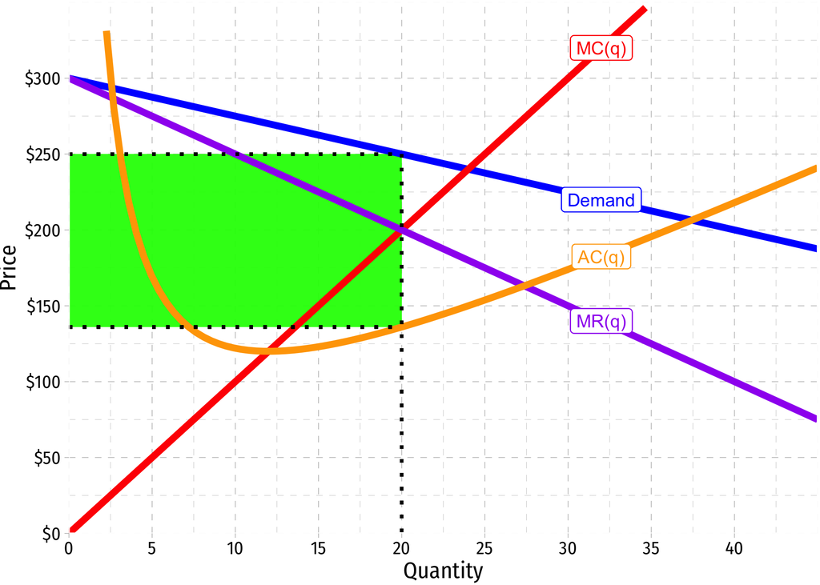